# Homework of all time

## Answer:

$(X_{1},X_{2}) \sim N(0, 0, 1, 1, 0.9)$ The conditional densities of a bivariate normal distribution are univariate normal with parameters
$$\begin{align*}
&E[X_{2}|x_{1}]=\mu_{1}+\rho\frac{\sigma_{2}}{\sigma_{1}}(x_{1}-\mu_{1})=0.9x_{1}\\
&Var(X_{2|x_{1}})=(1-\rho^{2})\sigma_{2}^{2}=0.19\\
\end{align*}$$
and the chain is generated by sampling from

$$\begin{align*}
&f(x_{1}|x_{2}) \sim
N(\mu_{1}+\frac{\rho\sigma_{1}}{\sigma_{2}}(x_{2}-\mu_{2}),(1-\rho^{2})\sigma_{1}^{2})
\sim N(0.9x_{2},0.19)\\
&f(x_{2}|x_{1}) \sim
N(\mu_{2}+\frac{\rho\sigma_{2}}{\sigma_{1}}(x_{1}-\mu_{1}),(1-\rho^{2})\sigma_{2}^{2})
\sim N(0.9x_{1},0.19)\\
\end{align*}$$

*step1*

Write down functions needed for this matter:

function “MC_bnorm” to generate a bivariate normal chain using Gibbs sampler method, the initialized value is passed through parameter mu_i1 and mu_i2 to X and Y,N stands for the length of chain and X jotting down the matrix storing the chain.

```r
rm(list = ls())
set.seed(123)
MC_bnorm <- function(X, N, mu_i1, mu_i2){
    rho <- .9
    #correlation
    mu1 <- mu2 <- 0
    sigma1 <-sigma2 <- 1
    s1 <- sqrt(1-rho^2)*sigma1
    s2 <- sqrt(1-rho^2)*sigma2
    X[1, ] <- c(mu_i1, mu_i2) #initialize
    for (i in 2:N) {
        y <- X[i-1, 2]
        m1 <- mu1 + rho * (y - mu2) * sigma1/sigma2
        X[i, 1] <- rnorm(1, m1, s1)
        x <- X[i, 1]
        m2 <- mu2 + rho * (x - mu1) * sigma2/sigma1
        X[i, 2] <- rnorm(1, m2, s2)
        }
    return(X)
}
```

function “cal_R_hat” to calculate the value of $\hat{R}$ with a parameter called “psi”, which is a matrix containing cumulative sum of a Markov chain

```r
cal_R_hat <- function(psi) {
        # psi[i,j] is the statistic psi(X[i,1:j])
        # for chain in i-th row of X
    psi <- as.matrix(psi)
    n <- ncol(psi)
    k <- nrow(psi)
    psi.means <- rowMeans(psi)     #row means
    B <- n * var(psi.means)        #between variance est.
    psi.w <- apply(psi, 1, "var")  #within variances
    W <- mean(psi.w)               #within est.
    v.hat <- W*(n-1)/n + (B/n)
    r.hat <- v.hat / W
    return(r.hat)
}
```

function “Gelman” to perform a Gelman-Rubin method.Its parameter n stands for the length of the chain, b for the length to burn, k for times of replicate. And because the chain generated in this problem actually contains two arrays, which stands for the chain of X and Y.Hence if the parameter “margin” is T or default value, this function perform Gelman-Rubin method on X and likewise if the value of margin is F then this function erform Gelman-Rubin method on Y.

```r
Gelman <- function(n, b, k, margin = T){
    x_i <- c(0, 0, 5, 5, -5, -5, 10, 10)
    X <- matrix(0, nrow = k, ncol=n)
    for (i in 1:k){
            tmp <- matrix(0, N, 2)
            tmp <- MC_bnorm(tmp, N, x_i[2 * i - 1], x_i[2 * i])
        if(margin)
            {X[i, ] <- tmp[, 1]}
        else
            {X[i, ] <- tmp[, 2]}
        }
    psi <- t(apply(X, 1, cumsum))
    for (i in 1:nrow(psi))
        psi[i,] <- psi[i,] / (1:ncol(psi))
    print(cal_R_hat(psi))
    for (i in 1:k)
        plot(psi[i, (b+1):n],
             type="l",
             xlab=i,
             ylab=bquote(psi))
    rhat <- rep(0, n)
    for (j in (b+1):n)
        rhat[j] <- cal_R_hat(psi[,1:j])
    plot(rhat[(b+1):n], type="l", xlab="n - burn", ylab="R")
    abline(h=1.2, lty=2)
}
```

*step2*

generate a bivariate normal chain $(X_{t}, Y_{t})$ with zero means, unit standard deviations, and correlation 0.9. Plot the generated sample after discarding burn-in samples of 100.

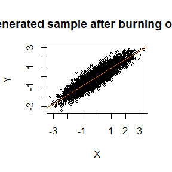

```r
N <- 5000 #length of chain
 burn <- 100 #burn-in length
 X <- matrix(0, N, 2) #the chain, a bivariate sample
 X <- MC_bnorm(X, N, 0, 0)
 b <- burn + 1
 X <- X[b:N, ]
X_f <- as.data.frame(X)
names(X_f)[1] <- "x"
names(X_f)[2] <- "y"
X_l <- lm(y ~ x, X_f)
plot(X,
     main="Generated sample after burning out 0.1k",
     cex=.5,
     xlab=bquote(X),
     ylab=bquote(Y),
     ylim=range(X[,2]))
abline(X_l, col = "Chocolate")
```

*step3*

```r
(X_reg <- summary(X_l))
```

```
##
## Call:
## lm(formula = y ~ x, data = X_f)
##
## Residuals:
##      Min       1Q   Median       3Q      Max
## -1.50529 -0.29308 -0.00353  0.29498  1.68633
##
## Coefficients:
##              Estimate Std. Error t value Pr(>|t|)
## (Intercept) -0.006521   0.006215  -1.049    0.294
## x            0.901857   0.006359 141.822   <2e-16 ***
## ---
## Signif. codes:  0 '***' 0.001 '**' 0.01 '*' 0.05 '.' 0.1 ' ' 1
##
## Residual standard error: 0.435 on 4898 degrees of freedom
## Multiple R-squared:  0.8042, Adjusted R-squared:  0.8041
## F-statistic: 2.011e+04 on 1 and 4898 DF,  p-value: < 2.2e-16
```

*step4*

Use the Gelman-Rubin method to monitor convergence of the chain, and run the chain until it converges approximately to the target distribution according to $\hat{R}<1.2$

```r
k <- 4
Gelman(N, burn, k, T)
```

```
## [1] 1.078574
```

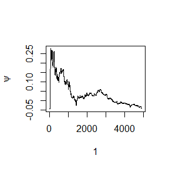

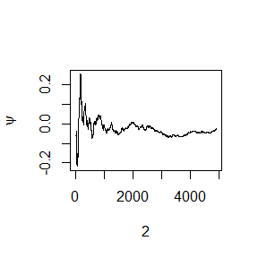

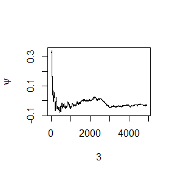

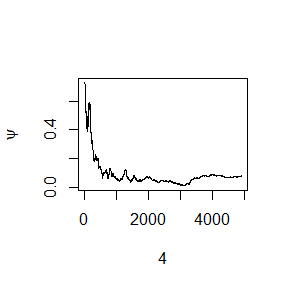

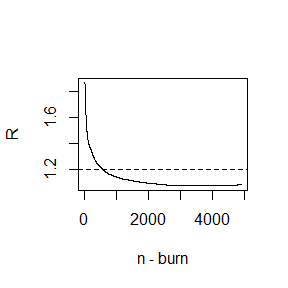

```r
Gelman(N, burn, k, F)
```

```
## [1] 1.160852
```

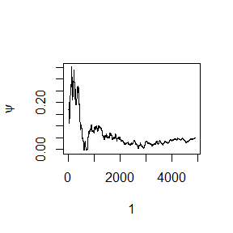

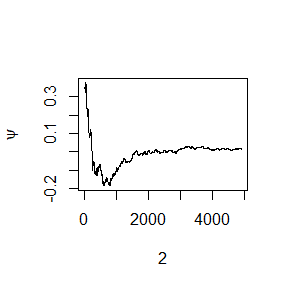

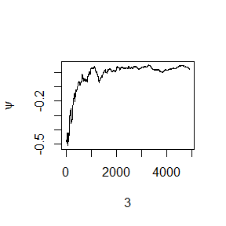

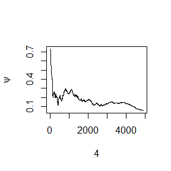

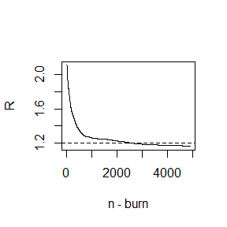

```r
rm(list=ls())
gc()
```

```
##           used (Mb) gc trigger (Mb) max used  (Mb)
## Ncells  786813 42.1    1366928 73.1  1366928  73.1
## Vcells 1641539 12.6    9197056 70.2 45121357 344.3
```

**conclusion plus:** From the result we could see that X converges after 600 while Y converges after 2500 iterations.So this bivariate normal chain $(X_{t}, Y_{t})$ generated with Gibbs sampler method should converge after 2500 iterations.

## 9th

## Question1

From $M=a_{M}+\alpha X+e_{M},\quad Y=a_{Y}+\beta M+ \gamma X + e_{Y}, \quad e_{M},e_{Y} \quad iid \quad \sim N(0,1)$ ,test the performance of these three method: $(1) \quad \alpha = 0 \quad (2) \beta = 0 \quad (3) \alpha = \beta =0$ under the model of $(1) \quad \alpha=\beta=0, \quad (2) \quad \alpha=0 \quad \beta=1 \quad (3) \quad \alpha=1 \quad beta=0$while$\gamma=1$

## Answer1

Use R package “mediation” in three setted models:

*step0*

write a function to perform objective test:

```r
test <- function(alpha, beta, gamma, N, X, em, ey){
    a_m <- 1
    a_y <- 1
    M <- a_m + alpha * X + em
    Y <- a_y + beta * M +gamma * X + ey
    data.one <- data.frame(X, M, Y)
    X.M <- lm(M ~ X, data = data.one)
    X_M.Y <- lm(Y ~ X + M, data = data.one)
    cont <- mediate(X.M, X_M.Y, treat = "X", mediator = "M", sims = 100, boot = T)
    tmp1 <- summary(X.M)
    tmp2 <- summary(X_M.Y)
    tmp3 <- summary(cont)
    print(tmp1) #print the result regression of x to M and X,M to Y as well as result of using mediation package
    print(tmp2)
    print(tmp3)
    plot(cont)
}
```

*step1*

**model 1:** $\alpha=\beta=0 \quad \gamma=1$  
**model 2:** $\alpha=0 \quad \beta=1 \quad \gamma=1$  
**model 3:** $\alpha=1 \quad \beta=0 \quad \gamma=1$

```r
library(mediation)
set.seed(123)
gamma <- 1
N <- 1e3
em <- rnorm(N)
ey <- rnorm(N)
X <- rpois(N, 1)
for (alpha in 0:1) {
    for (beta in 0:1) {
        if((alpha ==1) && (beta ==1)) break
        test(alpha, beta, gamma, N, X, em, ey)
    }
}
```

```
##
## Call:
## lm(formula = M ~ X, data = data.one)
##
## Residuals:
##     Min      1Q  Median      3Q     Max
## -2.8247 -0.6474 -0.0082  0.6559  3.1959
##
## Coefficients:
##             Estimate Std. Error t value Pr(>|t|)
## (Intercept)  1.04510    0.04427  23.606   <2e-16 ***
## X           -0.03017    0.03255  -0.927    0.354
## ---
## Signif. codes:  0 '***' 0.001 '**' 0.01 '*' 0.05 '.' 0.1 ' ' 1
##
## Residual standard error: 0.9918 on 998 degrees of freedom
## Multiple R-squared:  0.0008604,  Adjusted R-squared:  -0.0001408
## F-statistic: 0.8594 on 1 and 998 DF,  p-value: 0.3541
##
##
## Call:
## lm(formula = Y ~ X + M, data = data.one)
##
## Residuals:
##     Min      1Q  Median      3Q     Max
## -3.0273 -0.6918  0.0037  0.7093  3.2912
##
## Coefficients:
##             Estimate Std. Error t value Pr(>|t|)
## (Intercept)  0.95356    0.05611  16.994  < 2e-16 ***
## X            0.99943    0.03306  30.231  < 2e-16 ***
## M            0.08803    0.03214   2.739  0.00627 **
## ---
## Signif. codes:  0 '***' 0.001 '**' 0.01 '*' 0.05 '.' 0.1 ' ' 1
##
## Residual standard error: 1.007 on 997 degrees of freedom
## Multiple R-squared:  0.4792, Adjusted R-squared:  0.4781
## F-statistic: 458.7 on 2 and 997 DF,  p-value: < 2.2e-16
##
##
## Causal Mediation Analysis
##
## Nonparametric Bootstrap Confidence Intervals with the Percentile Method
##
##                Estimate 95% CI Lower 95% CI Upper p-value
## ACME           -0.00266     -0.01089         0.00    0.42
## ADE             0.99943      0.94391         1.06  <2e-16 ***
## Total Effect    0.99677      0.93961         1.06  <2e-16 ***
## Prop. Mediated -0.00266     -0.01123         0.00    0.42
## ---
## Signif. codes:  0 '***' 0.001 '**' 0.01 '*' 0.05 '.' 0.1 ' ' 1
##
## Sample Size Used: 1000
##
##
## Simulations: 100
```

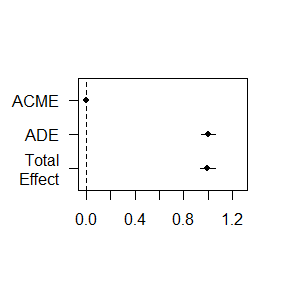

```
##
## Call:
## lm(formula = M ~ X, data = data.one)
##
## Residuals:
##     Min      1Q  Median      3Q     Max
## -2.8247 -0.6474 -0.0082  0.6559  3.1959
##
## Coefficients:
##             Estimate Std. Error t value Pr(>|t|)
## (Intercept)  1.04510    0.04427  23.606   <2e-16 ***
## X           -0.03017    0.03255  -0.927    0.354
## ---
## Signif. codes:  0 '***' 0.001 '**' 0.01 '*' 0.05 '.' 0.1 ' ' 1
##
## Residual standard error: 0.9918 on 998 degrees of freedom
## Multiple R-squared:  0.0008604,  Adjusted R-squared:  -0.0001408
## F-statistic: 0.8594 on 1 and 998 DF,  p-value: 0.3541
##
##
## Call:
## lm(formula = Y ~ X + M, data = data.one)
##
## Residuals:
##     Min      1Q  Median      3Q     Max
## -3.0273 -0.6918  0.0037  0.7093  3.2912
##
## Coefficients:
##             Estimate Std. Error t value Pr(>|t|)
## (Intercept)  0.95356    0.05611   16.99   <2e-16 ***
## X            0.99943    0.03306   30.23   <2e-16 ***
## M            1.08803    0.03214   33.85   <2e-16 ***
## ---
## Signif. codes:  0 '***' 0.001 '**' 0.01 '*' 0.05 '.' 0.1 ' ' 1
##
## Residual standard error: 1.007 on 997 degrees of freedom
## Multiple R-squared:  0.6675, Adjusted R-squared:  0.6669
## F-statistic:  1001 on 2 and 997 DF,  p-value: < 2.2e-16
##
##
## Causal Mediation Analysis
##
## Nonparametric Bootstrap Confidence Intervals with the Percentile Method
##
##                Estimate 95% CI Lower 95% CI Upper p-value
## ACME            -0.0328      -0.1100         0.03    0.34
## ADE              0.9994       0.9403         1.07  <2e-16 ***
## Total Effect     0.9666       0.8722         1.05  <2e-16 ***
## Prop. Mediated  -0.0340      -0.1245         0.03    0.34
## ---
## Signif. codes:  0 '***' 0.001 '**' 0.01 '*' 0.05 '.' 0.1 ' ' 1
##
## Sample Size Used: 1000
##
##
## Simulations: 100
```

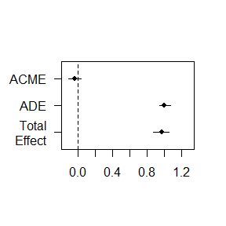

```
##
## Call:
## lm(formula = M ~ X, data = data.one)
##
## Residuals:
##     Min      1Q  Median      3Q     Max
## -2.8247 -0.6474 -0.0082  0.6559  3.1959
##
## Coefficients:
##             Estimate Std. Error t value Pr(>|t|)
## (Intercept)  1.04510    0.04427   23.61   <2e-16 ***
## X            0.96983    0.03255   29.80   <2e-16 ***
## ---
## Signif. codes:  0 '***' 0.001 '**' 0.01 '*' 0.05 '.' 0.1 ' ' 1
##
## Residual standard error: 0.9918 on 998 degrees of freedom
## Multiple R-squared:  0.4708, Adjusted R-squared:  0.4702
## F-statistic: 887.8 on 1 and 998 DF,  p-value: < 2.2e-16
##
##
## Call:
## lm(formula = Y ~ X + M, data = data.one)
##
## Residuals:
##     Min      1Q  Median      3Q     Max
## -3.0273 -0.6918  0.0037  0.7093  3.2912
##
## Coefficients:
##             Estimate Std. Error t value Pr(>|t|)
## (Intercept)  0.95356    0.05611  16.994  < 2e-16 ***
## X            0.91140    0.04543  20.064  < 2e-16 ***
## M            0.08803    0.03214   2.739  0.00627 **
## ---
## Signif. codes:  0 '***' 0.001 '**' 0.01 '*' 0.05 '.' 0.1 ' ' 1
##
## Residual standard error: 1.007 on 997 degrees of freedom
## Multiple R-squared:  0.4792, Adjusted R-squared:  0.4781
## F-statistic: 458.7 on 2 and 997 DF,  p-value: < 2.2e-16
##
##
## Causal Mediation Analysis
##
## Nonparametric Bootstrap Confidence Intervals with the Percentile Method
##
##                Estimate 95% CI Lower 95% CI Upper p-value
## ACME             0.0854       0.0286         0.15  <2e-16 ***
## ADE              0.9114       0.8196         1.00  <2e-16 ***
## Total Effect     0.9968       0.9394         1.06  <2e-16 ***
## Prop. Mediated   0.0857       0.0277         0.15  <2e-16 ***
## ---
## Signif. codes:  0 '***' 0.001 '**' 0.01 '*' 0.05 '.' 0.1 ' ' 1
##
## Sample Size Used: 1000
##
##
## Simulations: 100
```

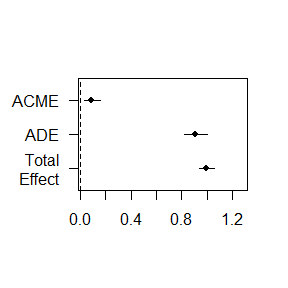

```r
rm(list=ls())
gc()
```

```
##           used  (Mb) gc trigger  (Mb) max used  (Mb)
## Ncells 2288193 122.3    4628665 247.2  4554334 243.3
## Vcells 3963894  30.3    9197056  70.2 45121357 344.3
```

**conclusion1** From the result of linear regression and mediation, we could see that alpha equals 0 significantly in the first linear regression part, but beta doesn’t under significant level of 0.05,whose p value is 0.00627.So in this model alpha=0 while beta!=0.Under the result of ACME of function “mediate”,which significantly equals to 0 under the p value of 0.42,indicating that alpha * beta =0.  
So to speak the first type of error of test of alpha * beta is 0.42 while type I error in test No 1 is 0.35, in test No2 is 0.00627,in test No3 is 0.35,So these three test can’t control type I error of the original test.

**conclusion3** From the result of linear regression and mediation, we could see that alpha equals 1 significantly in the first linear regression part, but beta doesn’t under significant level of 0.05,whose p value is 0.00627.So in this model alpha=1 while beta!=0.Under the result of ACME of function “mediate”,which doesn’t significantly equals to 0 either,indicating that alpha * beta !=0.  
So to speak the first type of error of test of alpha * beta is 0 while type I error in test No2 is 0.00627,in test No3 is 0.00627,So these three test can’t control type I error of the original test.

## Question2

**From** $P(Y = 1|X_{1}, X_{2}, X_{3})=expit(a+b_{1}x_{1}+b_{2}x_{2}+b_{3}x_{3})$,  
**where** $X_{1} \sim P(1)$, $X_{2} \sim Exp(1)$, $X_{3} \sim B(1,0.5)$  
**(1) Write down a function to calculate alpha given** $N,b_{1},b_{2},b_{3},f_{0}$  
**(2) Call the function wrote above with parameter** $N=10^{6}, \quad b_{1}=0, \quad b_{2}=1, \quad b_{3}=-1,\quad f_{0}=0.1,0.01,0.001,0.0001$  
**(3)Plot** $f_{0}$ **vs** $alpha$

## Answer2

*step1*

```r
logi.reg <- function(N, b1, b2, b3, f0){
    x1 <- rpois(N, 1)
    x2 <- rexp(N, 1)
    x3 <- rbinom(N, 1, .5)
    g <- function(alpha){
        tmp <- exp(-alpha - b1 * x1 - b2 * x2 - b3 * x3)
        p <- 1/(1 + tmp)
        mean(p) - f0
    }
    solution <- uniroot(g,c(-20,0))
    return(solution$root)
}
```

*step2*

```r
root<- numeric(4)
f<- numeric(4)
f
```

```
## [1] 0 0 0 0
```

```r
for (i in 1:4 ) {
    f[i] <- 1 / 10 ^ i
    root[i] <- logi.reg(1e6, 0, 1, -1, f[i])
    paste("when f0 is: ", f, "root is: ", root[i], "\n")
}
```

*step3*

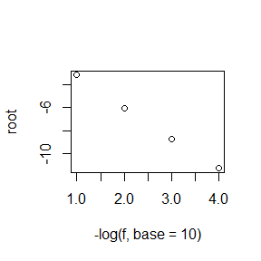

```r
plot(-log(f, base = 10), root)
```

```r
rm(list=ls())
gc()
```

```
##           used  (Mb) gc trigger  (Mb) max used  (Mb)
## Ncells 2287708 122.2    4628665 247.2  4554334 243.3
## Vcells 3956990  30.2   14043944 107.2 45121357 344.3
```

**conclusion** We could see that logf0 and alpha are approximately linear

## 10th

## Question:

handwritten homework about EM algorithm

## Answer:

*step1*

$For \quad X_{1},...,X_{n} \quad iid \quad \sim Exp(\lambda)$ So the likelihood function is :$L_{O}(\lambda)=\prod_{i = 1}^{n} P_{\lambda}(u_{i} \le x_{i} \le v_{i})=\prod_{i = 1}^{n} (e^{- \lambda u_{i}}-e^{- \lambda v_{i}})$  
$l_{O}(\lambda)=\sum_{i = 1}^{n} \log(e^{- \lambda u_{i}}-e^{- \lambda v_{i}})$  
From $\displaystyle \frac{\partial l_{O}(\lambda)}{\partial \lambda}=\sum_{i = 1}^{n} \frac{v_{i}e^{- \lambda v_{i}} - u_{i}e^{- \lambda u_{i}}}{e^{- \lambda u_{i}}-e^{- \lambda v_{i}}}=0$  
we could derive Observed data likelihood estimation by solving this nonlinear equation afterwards using r package “BB”

Complete data likelihood:$L_{C}(\lambda)=\prod_{i = 1}^{n} \lambda e^{- \lambda x_{i}}= \lambda^{n}e^{- \lambda \sum_{i = 1}^{n} x_{i}}$ So$l_{C}(\lambda)=n \log(\lambda)-\lambda \sum_{i = 1}^{n} x_{i}$  
So the expectation being:$E(l_{C}(\lambda|u_{i}, v_{i}))=n \log(\lambda)- \lambda \sum_{i = 1}^{n} E(x_{i}|u_{i},v_{i})$

From $P(x_{i}|u_{i}, v_{i})=\frac{P(X_{i} \le x_{i})}{P(u_{i} \le X_{i} \le v_{i})}$

We could derive that $f(x_{i}|u_{i},v_{i})= \frac{\lambda e^{- \lambda x_{i}}}{e^{- \lambda u_{i}}-e^{- \lambda v_{i}}}$

So $E(x_{i}|u_{i},v_{i})=\int_{u_{i}}^{v_{i}} x_{i}f(x_{i}|u_{i},v_{i}) \; dx_{i}=\int_{u_{i}}^{v_{i}} x_{i} \frac{\lambda e^{- \lambda x_{i}}}{e^{- \lambda u_{i}}-e^{- \lambda v_{i}}} \; dx=\frac{u_{i}e^{- \lambda u_{i}}-v_{i}e^{- \lambda v_{i}}}{e^{- \lambda u_{i}}-e^{- \lambda v_{i}}}+ \frac{1}{\lambda}$  
Take this result back to the conditional expectation above: $E(l_{C}(\lambda|u_{i}, v_{i}))=n \log(\lambda)- \lambda (\sum_{i = 1}^{n} \frac{u_{i}e^{- \lambda u_{i}}-v_{i}e^{- \lambda v_{i}}}{e^{- \lambda u_{i}}-e^{- \lambda v_{i}}}+ \frac{n}{\lambda})$  
Now we turn to step M,which is to calculate the value of $\lambda$ when the expectation hit its maximum scale:  
$\displaystyle \frac{\partial E(l_{C}(\lambda|u_{i}, v_{i}))}{\partial \lambda}= \frac{n}{\lambda}-\sum_{i = 1}^{n} \frac{u_{i}e^{- \lambda u_{i}}-v_{i}e^{- \lambda v_{i}}}{e^{- \lambda u_{i}}-e^{- \lambda v_{i}}}-\lambda \sum_{i = 1}^{n}\displaystyle \frac{\partial }{\partial \lambda} \frac{u_{i}e^{- \lambda u_{i}}-v_{i}e^{- \lambda v_{i}}}{e^{- \lambda u_{i}}-e^{- \lambda v_{i}}}$  
$\hat{\lambda}_{1}=\frac{n}{ \frac{u_{i}e^{- \lambda_{0} u_{i}}-v_{i}e^{- \lambda_{0} v_{i}}}{e^{- \lambda_{0} u_{i}}-e^{- \lambda_{0} v_{i}}}+\frac{n}{\hat{\lambda_{0}}}}$  
Such that the recursive formula being:  
$\hat{\lambda}_{k}=\frac{n}{ \frac{u_{i}e^{- \lambda_{k-1} u_{i}}-v_{i}e^{- \lambda_{k-1} v_{i}}}{e^{- \lambda_{k-1} u_{i}}-e^{- \lambda_{k-1} v_{i}}}+\frac{n}{\hat{\lambda_{k-1}}}},k=1,2,...$  
If this recursive formula converges, than $\hat{\lambda}_{\infty}=\frac{n}{ \frac{u_{i}e^{- \lambda_{\infty} u_{i}}-v_{i}e^{- \lambda_{\infty} v_{i}}}{e^{- \lambda_{\infty} u_{i}}-e^{- \lambda_{\infty} v_{i}}}+\frac{n}{\hat{\lambda_{\infty}}}}$  
Using $|\hat{\lambda_{k}}-\hat{\lambda_{k-1}}|=|\frac{n}{ \frac{u_{i}e^{- \lambda_{k-1} u_{i}}-v_{i}e^{- \lambda_{k-1} v_{i}}}{e^{- \lambda_{k-1} u_{i}}-e^{- \lambda_{k-1} v_{i}}}+\frac{n}{\hat{\lambda_{k-1}}}}-\frac{n}{ \frac{u_{i}e^{- \lambda_{k-2} u_{i}}-v_{i}e^{- \lambda_{k-2} v_{i}}}{e^{- \lambda_{k-2} u_{i}}-e^{- \lambda_{k-2} v_{i}}}+\frac{n}{\hat{\lambda_{k-2}}}}|$  
Using contraction mapping we could prove that lambda hat converges.

*step2*

write function “EM_way” to perform EM method on the given data and use r package to get the estimate value of lambda from solving the equation of likelihood function of observed data

```r
EM_way <- function(interval, lam_0){
    n <- nrow(interval)
    summ <- 0
    for (i in 1:n) {
        summ <-summ + (interval[i, 1] * exp(-lam_0 * interval[i, 1])-interval[i, 2] * exp(-lam_0 * interval[i, 2]))/(exp(-lam_0 * interval[i, 1])-exp(-lam_0 * interval[i, 2]))
    }
   lam_1 <- n / (summ + n/lam_0)
   if(abs(lam_0 - lam_1) <= 1e-10) return(lam_1)
   else return(EM_way(interval, lam_1))
}
ob_way <- function(lam_o){
    for (i in 1:10) {
    ob<-ob+(interval[i, 2]*exp(-interval[i, 2]*lam_o)-interval[i, 1]*exp(-interval[i, 1]*lam_o))/(exp(-interval[i, 2]*lam_o)-exp(-interval[i, 1]*lam_o))
    }
  f<-ob

  f
}
```

*step3*

install package “BB” to solve nonlinear equation

```r
library(BB)
ob <- 0
lam_0 <- 1
interval <- matrix(c(11, 8, 27, 13, 16, 0, 23, 10, 24, 2, 12, 9, 28, 14, 17, 1, 24, 11, 25, 3), 10, 2)
paste("lambda hat derived from EM method is:", EM_way(interval, lam_0))
```

```
## [1] "lambda hat derived from EM method is: 0.071973499625121"
```

```r
starl<-c(0.7)
result=dfsane(starl,ob_way,control = list(maxit=2500,trace=FALSE))
paste("lambda hat derived from observed data is : ", result$par)
```

```
## [1] "lambda hat derived from observed data is :  0.0719734996274632"
```

```r
rm(list=ls())
```

**conclusion:** From the numerical solution we could see that the result of this two methods are approximately same.

## Question:

Why do you need to use unlist() to convert a list to an atomic vector? Why doesn’t as.vector() work?

## Answer:

As the book suggested at the beginning of 2.1:“Vectors come in two flavours: atomic vectors and lists.”List is a type of vector already,Using as.vector on a list won’t convert it into a atomic vector,Only to let the list remain as it is.

```r
test.l.1 <-list(1:4, "a", T, list())
test.l.2 <- as.vector(test.l.1)
test.l.3 <- unlist(test.l.1)
str(test.l.1)
```

```
## List of 4
##  $ : int [1:4] 1 2 3 4
##  $ : chr "a"
##  $ : logi TRUE
##  $ : list()
```

```r
str(test.l.2)
```

```
## List of 4
##  $ : int [1:4] 1 2 3 4
##  $ : chr "a"
##  $ : logi TRUE
##  $ : list()
```

```r
str(test.l.3)
```

```
##  chr [1:6] "1" "2" "3" "4" "a" "TRUE"
```

```r
rm(list=ls())
```

## Question:

Why is 1 == “1” true? Why is -1 < FALSE true? Why is “one” < 2 false?

## Answer:

Coercion often happens automatically. Most mathematical functions (+, log, abs, etc.) will coerce to a double or integer, and most logical operations (&, |, any, etc) will coerce to a logical.  
The hierarchy for coercion is: logical < integer < numeric < character.  
So in the first case where 1 is compared with”1”, the double atomic vector is coerced to character atomic vector and no doubt “1” == “1” is true.  
In the second case FALSE is coerced to double atomic vector 0 and -1 < 0 returns true apparently.  
However when “one” is compared with 2 in the third case, 2 is coerced to character atomic vector “2” and the expression is comparing “one” with “2” actually,which is the comparison of strings.I looked up and find out the comparing rules of R may varies:“Comparison of strings in character vectors is lexicographic within the strings using the collating sequence of the locale in use: see locales. The collating sequence of locales such as en_US is normally different from C (which should use ASCII) and can be surprising.”.So in this case “one” >= “2”,i.e.”o” > “2” could be the comparison of the ASCII.

## Question:

What does dim() return when applied to a vector?

## Answer:

returns NULL

```r
dim(1:10)
```

[output not shown]

```r
dim(list(1, "a", T))
```

[output not shown]

```r
rm(list=ls())
```

## Question:

If is.matrix(x) is TRUE, what will is.array(x) return?

## Answer:

It would return TRUE  
As it is written in the description of as.matrix() and as.array() function:“is.matrix returns TRUE if x is a vector and has a”dim” attribute of length 2 and FALSE otherwise.”  
“An array in R can have one, two or more dimensions. It is simply a vector which is stored with additional attributes giving the dimensions (attribute”dim”) and optionally names for those dimensions (attribute “dimnames”).A two-dimensional array is the same thing as a matrix.”  
So a matrix is also an array,is.array(x) would return TRUE if is.matrix(x) returns TRUE in the first place.

## Question:

What attributes does a data frame possess?

## Answer:

A data frame shares properties of both the matrix and the list.So similar to matrices, data frames will have a dimension attribute. In addition, data frames can also have additional attributes such as row names, column names, and comments.

```r
df <- data.frame(x = 1:4, y = c("a", "b", "c", "d"), stringAsFactors = FALSE)
str(df)
```

```
## 'data.frame':    4 obs. of  3 variables:
##  $ x              : int  1 2 3 4
##  $ y              : chr  "a" "b" "c" "d"
##  $ stringAsFactors: logi  FALSE FALSE FALSE FALSE
```

```r
attributes(df)
```

```
## $names
## [1] "x"               "y"               "stringAsFactors"
##
## $class
## [1] "data.frame"
##
## $row.names
## [1] 1 2 3 4
```

```r
rm(list=ls())
```

## Question:

What does as.matrix() do when applied to a data frame with columns of different types?

## Answer:

as.matrix() convert a data frame with columns of different types to a matrix whose elements’ type got coerced to the most “flexible” type as the rank mentioned above: logical < integer < numeric < character.

```r
df <- data.frame(x = 1:4, y = c("a", "b", "c", "d"), z <- c(T, T, F, T), stringAsFactors = FALSE)
test <- as.matrix(df)
typeof(test)
```

```
## [1] "character"
```

```r
str(test)
```

```
##  chr [1:4, 1:4] "1" "2" "3" "4" "a" "b" "c" "d" "TRUE" "TRUE" "FALSE" ...
##  - attr(*, "dimnames")=List of 2
##   ..$ : NULL
##   ..$ : chr [1:4] "x" "y" "z....c.T..T..F..T." "stringAsFactors"
```

```r
rm(list=ls())
```

## Question:

Can you have a data frame with 0 rows? What about 0 columns?

## Answer:

We could make a data frame with 0 rows by data.frame() function

```r
test=data.frame(col1=character(0),col2=numeric(0),col3=logical(0))
str(test)
```

```
## 'data.frame':    0 obs. of  3 variables:
##  $ col1: chr
##  $ col2: num
##  $ col3: logi
```

```r
rm(list=ls())
```

or transform a matrix with no rows to a data frame

```r
test=matrix(data=NA,nrow = 0,ncol = 3)
test=as.data.frame(test)
colnames(test)=c("col1","col2","col3")
str(test)
```

```
## 'data.frame':    0 obs. of  3 variables:
##  $ col1: logi
##  $ col2: logi
##  $ col3: logi
```

```r
rm(list=ls())
```

```r
df.empty <- data.frame(row1="",row2="",row3="")[-1,]
str(df.empty)
```

```
## 'data.frame':    0 obs. of  3 variables:
##  $ row1: chr
##  $ row2: chr
##  $ row3: chr
```

```r
rm(list=ls())
```

## 11th

## Question1:

The function below scales a vector so it falls in the range [0, 1]. How would you apply it to every column of a data frame? How would you apply it to every numeric column in a data frame?  
scale01 <- function(x) {  
rng <- range(x, na.rm = TRUE) (x - rng[1]) / (rng[2] - rng[1])  
}

## Answer:

Since data frames are also lists, lapply() is also useful when one want to do something to each column of a data frame.

*step1*

```r
library(knitr)
scale01 <- function(x) {
  rng <- range(x, na.rm = TRUE)
  (x - rng[1]) / (rng[2] - rng[1])
}
df <- data.frame(lapply(mtcars,function(x) scale01(x) ))
df
```

```
##          mpg cyl       disp         hp       drat         wt       qsec vs am
## 1  0.4510638 0.5 0.22175106 0.20494700 0.52534562 0.28304781 0.23333333  0  1
## 2  0.4510638 0.5 0.22175106 0.20494700 0.52534562 0.34824853 0.30000000  0  1
## 3  0.5276596 0.0 0.09204290 0.14487633 0.50230415 0.20634109 0.48928571  1  1
## 4  0.4680851 0.5 0.46620105 0.20494700 0.14746544 0.43518282 0.58809524  1  0
## 5  0.3531915 1.0 0.72062859 0.43462898 0.17972350 0.49271286 0.30000000  0  0
## 6  0.3276596 0.5 0.38388626 0.18727915 0.00000000 0.49782664 0.68095238  1  0
## 7  0.1659574 1.0 0.72062859 0.68197880 0.20737327 0.52595244 0.15952381  0  0
## 8  0.5957447 0.0 0.18857570 0.03533569 0.42857143 0.42879059 0.65476190  1  0
## 9  0.5276596 0.0 0.17385882 0.15194346 0.53456221 0.41856303 1.00000000  1  0
## 10 0.3744681 0.5 0.24070841 0.25088339 0.53456221 0.49271286 0.45238095  1  0
## 11 0.3148936 0.5 0.24070841 0.25088339 0.53456221 0.49271286 0.52380952  1  0
## 12 0.2553191 1.0 0.51060115 0.45229682 0.14285714 0.65379698 0.34523810  0  0
## 13 0.2936170 1.0 0.51060115 0.45229682 0.14285714 0.56686269 0.36904762  0  0
## 14 0.2042553 1.0 0.51060115 0.45229682 0.14285714 0.57964715 0.41666667  0  0
```

[output cut: 51 more lines]

```r
rm(list=ls())
```

*step2*

Noted that this function needs numeric input,we could use an if clause to only process numeric columns and else to return non-numeric columns as it is.

```r
scale01 <- function(x) {
  rng <- range(x, na.rm = TRUE)
  (x - rng[1]) / (rng[2] - rng[1])
}
df <- data.frame(lapply(iris, function(x) if (is.numeric(x)) scale01(x) else x))
df
```

```
##     Sepal.Length Sepal.Width Petal.Length Petal.Width    Species
## 1     0.22222222  0.62500000   0.06779661  0.04166667     setosa
## 2     0.16666667  0.41666667   0.06779661  0.04166667     setosa
## 3     0.11111111  0.50000000   0.05084746  0.04166667     setosa
## 4     0.08333333  0.45833333   0.08474576  0.04166667     setosa
## 5     0.19444444  0.66666667   0.06779661  0.04166667     setosa
## 6     0.30555556  0.79166667   0.11864407  0.12500000     setosa
## 7     0.08333333  0.58333333   0.06779661  0.08333333     setosa
## 8     0.19444444  0.58333333   0.08474576  0.04166667     setosa
## 9     0.02777778  0.37500000   0.06779661  0.04166667     setosa
## 10    0.16666667  0.45833333   0.08474576  0.00000000     setosa
## 11    0.30555556  0.70833333   0.08474576  0.04166667     setosa
## 12    0.13888889  0.58333333   0.10169492  0.04166667     setosa
## 13    0.13888889  0.41666667   0.06779661  0.00000000     setosa
## 14    0.00000000  0.41666667   0.01694915  0.00000000     setosa
```

[output cut: 136 more lines]

```r
rm(list=ls())
```

## Question2:

1. Use vapply() to:
1. Compute the standard deviation of every column in a numeric data frame.
2. Compute the standard deviation of every numeric column in a mixed data frame. (Hint: you’ll need to use vapply() twice.)

## Answer:

*step1*

for pure numeric data frame we choose mtcars:

```r
library(knitr)
data <- vapply(mtcars,
       sd,
       numeric(1))
kable(data,
      "pipe",
      align = "l")
```

|  | x |
| --- | --- |
| mpg | 6.0269481 |
| cyl | 1.7859216 |
| disp | 123.9386938 |
| hp | 68.5628685 |
| drat | 0.5346787 |
| wt | 0.9784574 |
| qsec | 1.7869432 |
| vs | 0.5040161 |
| am | 0.4989909 |
| gear | 0.7378041 |
| carb | 1.6152000 |

```r
rm(list=ls())
```

*step2*

Using the first vapply inside to get the numeric column of a mixed data frame and use the other vapply to do the calculation:

```r
library(knitr)
data <- vapply(iris[vapply(iris, is.numeric, logical(1))],
       sd,
       numeric(1))
kable(data,
      "pipe",
      align = "l")
```

|  | x |
| --- | --- |
| Sepal.Length | 0.8280661 |
| Sepal.Width | 0.4358663 |
| Petal.Length | 1.7652982 |
| Petal.Width | 0.7622377 |

```r
rm(list=ls())
```

## Question3:

Implement a Gibbs sampler to generate a bivariate normal chain (Xt, Yt) with zero means, unit standard deviations, and correlation 0.9.  
• Write an Rcpp function.  
• Compare the corresponding generated random numbers with pure R language using the function “qqplot”.  
• Compare the computation time of the two functions with the function “microbenchmark”.

## Answer:

install package {RVAideMemoire} to use function “mqqnorm” for drawing QQ-plots to assess multivariate normality generated by Gibbs methods of R and Cpp.

*step1*

```r
library(Rcpp)
cppFunction(code='NumericMatrix GibbsC(int N, double mu_i1, double mu_i2){
    NumericMatrix mat(N, 2);
    double rho = .9;
    double mu1 = 0, mu2 = 0;
    double sigma1 = 1, sigma2 = 1;
    double s1 = sqrt(1 - rho * rho) * sigma1;
    double s2 = sqrt(1 - rho * rho) * sigma2;
    double x =0, y = 0, m1 = 0, m2 = 0;
    NumericVector tmp(1);
    mat(0,0) = mu_i1;
    mat(0,1) = mu_i2;
    for (int i=1; i < N; ++i) {
        y = mat(i-1, 1);
        m1 = mu1 + rho * (y - mu2) * sigma1/sigma2;
        tmp = rnorm(1, m1, s1);
        mat(i, 0) = tmp[0];
        x = mat(i, 0);
        m2 = mu2 + rho * (x - mu1) * sigma2/sigma1;
        tmp = rnorm(1, m2, s2);
        mat(i, 1) = tmp[0];
    }
    return mat;
}')
```

*step2*

write function “GibbsR” to generate a bivariate normal chain whose parameters are the same as GibbsC’s.

```r
GibbsR <- function(N, mu_i1, mu_i2){
    X <- matrix(0, N, 2)
    rho <- .9
    #correlation
    mu1 <- mu2 <- 0
    sigma1 <-sigma2 <- 1
    s1 <- sqrt(1-rho^2)*sigma1
    s2 <- sqrt(1-rho^2)*sigma2
    X[1, ] <- c(mu_i1, mu_i2) #initialize
    for (i in 2:N) {
        y <- X[i-1, 2]
        m1 <- mu1 + rho * (y - mu2) * sigma1/sigma2
        X[i, 1] <- rnorm(1, m1, s1)
        x <- X[i, 1]
        m2 <- mu2 + rho * (x - mu1) * sigma2/sigma1
        X[i, 2] <- rnorm(1, m2, s2)
        }
    return(X)
}
```

*step3*

call both functions to generate bivariate normal chains Cnorm and Rnorm with zero means, unit standard deviations, and correlation 0.9 of the same length and initialize value.Draw qqplots of both chains to assess multivariate normality.

```r
library(Rcpp)
library(microbenchmark)
library(RVAideMemoire)
```

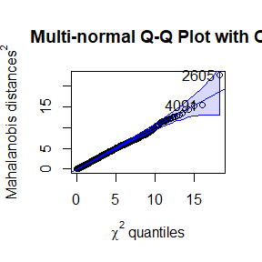

```
## [1] 2605 4091
```

```r
N <- 5000
burn <- 500
Cnorm <- matrix(0, N, 2)
Rnorm <- matrix(0, N, 2)
Cnorm_b <- matrix(0, N-burn, 2)
Rnorm_b <- matrix(0, N-burn, 2)
Cnorm <- GibbsC(N, 0, 0)
Rnorm <- GibbsR(N, 0, 0)
Cnorm_b <- Cnorm[burn:N ,]
Rnorm_b <- Rnorm[burn:N ,]
mqqnorm(Cnorm_b, main = "Multi-normal Q-Q Plot with C")
```

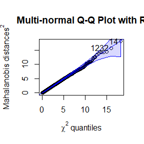

```
## [1]   14 1232
```

```r
mqqnorm(Rnorm_b, main = "Multi-normal Q-Q Plot with R")
```

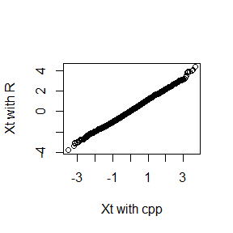

```r
qqplot(Cnorm[, 1],
       Rnorm[, 1],
       xlab = "Xt with cpp",
       ylab = "Xt with R")
```

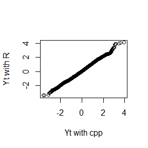

```r
qqplot(Cnorm[, 2],
       Rnorm[, 2],
       xlab = "Yt with cpp",
       ylab = "Yt with R")
```

**conclusion:** From the qqplots of chains in contrast with bivariate normal distribution we could see that both chains are approximately follow bivariate normal distribution.The qqplots of Xt and Yt of both chains imply that result of these two method are pretty much the same.

*step4*

Use function “microbenchmark” to computation time of the two functions

```r
ts <- microbenchmark(GibbsC(N, 0, 0), GibbsR(N, 0, 0))
ts
```

```
## Unit: milliseconds
##             expr     min      lq      mean   median      uq      max neval
##  GibbsC(N, 0, 0)  1.5055  1.5464  1.620803  1.59975  1.6328   2.7260   100
##  GibbsR(N, 0, 0) 16.1667 16.3777 20.030341 16.66845 21.9414 159.7736   100
```

```r
rm(list=ls())
```

**conclusion:** From the outcome of consuming time of both functions we could see that the speed of Cpp way is much faster than that of R way in generating bivariate normal chains